# PCA, cPCA, occPCA

Robin Tu

10/1/2019

### Recap of SVD and some nice properties:

SVD decomposes a $n \times p$ matrix $X = UDV^T$:

- $U$ is a left unitary $n \times n$ matrix. $U$ is the orthonormal eigenvectors for $XX^T = UDV^T (UDV^T)^T = UD^2U^T$
- $D$ is a rectangular diagonal $n\times p$ matrix
- $V^T$ is a right unitary $p\times p$ matrix. $V$ are the orthonormal eigenvectors for $X^TX=(UDV^T)^TUDV^T = VD^2V^T$.

Since $U$ and $V$ are unitary

- $U^T = U^{-1} \Rightarrow U^TU= I_{n}$
- $V^T = V^{-1} \Rightarrow VV^T= V^TV= I_{p}$

This decomposition can be thought of as rotation, scaling, and rotation again. SVD also allows you to compute the eigenvectors of the covariance matrix without calculating the covariance matrix and doing an eigen/spectral decomposition on the $p \times p$ matrix.

The diagonal elements of $D^2$ be described as the variance explained by each dimension. When $X$ is centered:

$$\begin{align*}
\text{Cov}\left(XV\right) &= V^T\text{Cov}\left(X\right)V\\
&=V^TX^TXV\\
&=V^TVD^2V^TV\\
&=D^2
\end{align*}$$

### Helper Functions:

#### Turning NA’s to Zeros.

```r
## convert NA values to zero
NAtoZero = function(mat){
  mat[is.na(mat)] <- 0
  return(mat)
}
```

#### Ploting diagnostics for Principal Components

```r
#screeplot for an SVD object
scree = function(svd_obj){
  var_explained <- svd_obj$d^2
  var_explained_plot <- data.table("Components" = 1:length(var_explained), "Value"=cumsum(var_explained)/(sum(var_explained)), "Analysis"="Total Prop. Explained")
  scree_plot <- data.table("Components" = 1:length(var_explained), "Value"=var_explained, "Analysis"="Variance")

  plot_dat <- rbind(var_explained_plot, scree_plot)

  ggplot(data = plot_dat)+
    geom_point(aes(x = Components, y = Value))+
    geom_line(aes(x = Components, y = Value), color = "dodgerblue3")+
    facet_grid(Analysis~., scales = "free")+
    ggtitle("Diagnostic Plots")
  }
```

#### Crude Tests

make sure my helper functions work as they should

```r
test_mat <- matrix(rnorm(1000*4, mean = 100, sd = 20), ncol = 4)

centered_scaled_obj <- scale(test_mat)
scaled_obj <- scale(test_mat, center = F, scale = apply(test_mat, 2, sd, na.rm=T))

# make sure the column means are close to zero (ie less than machine epsilon)
expect_equivalent(apply(centered_scaled_obj, 2, mean),expected = rep(0, 4))
# make sure variances are 1
expect_equivalent(apply(centered_scaled_obj, 2, var), expected = rep(1, 4))

# make sure the column means do not change
expect_equal(apply(scaled_obj, 2, mean), expected = colMeans(scaled_obj))
# make sure variances are 1
expect_equivalent(apply(scaled_obj, 2, var), expected = rep(1, 4))
```

### PCA, cPCA, occPCA functions:

#### PCA: Principal Component Analysis

PCA seeks to find the direction $v$ that maximizes the variance/covariance of $Xv$.

$$\begin{align*}
cov(Xv) &= v^TC_xv\\
\end{align*}$$

In other words, $v = \text{argmax}_{\|v\|_2=1}v^TC_x v$ where $C_x$ is the covariance matrix of $X$. This could be found using eigen/spectral decomposition, or using the matrix $V$ from the SVD decomposition, $X = UDV^T$. $V$ gives the eigenvectors corresponding to the rotation explaining the largest variance to the smallest variance.

Another way to look at PCA is one of minimizing the reconstruction error of a generative model. Suppose $x_i \approx f\left(\lambda_i\right)$, where the function
$$f\left(\lambda\right) = \mu + V_r\lambda$$
parameterizes an affine set of dimension $r$. $\mu \in \mathbb{R}^{p}$, $V_r \in \mathbb{R}^{p\times r}$ is an matrix with orthonormal columns and $\lambda \in \mathbb{R}^r$ is a parameter vector over samples. Finding the $V_r$ that minimizes:
$$\frac{1}{N}\sum^{N}_{i=1}{\|x_i - \mu - V_r\lambda_i\|^2_2}$$

For some $\mu$ and $\lambda$ yields the same solution. If data has been precentered, where $\mu = 0$ this simplifies to:
$$\frac{1}{N}\sum^{N}_{i=1}{\|x_i - V_rV_r^Tx_i\|^2_2}$$

An example of using PCA on the `iris` dataset:

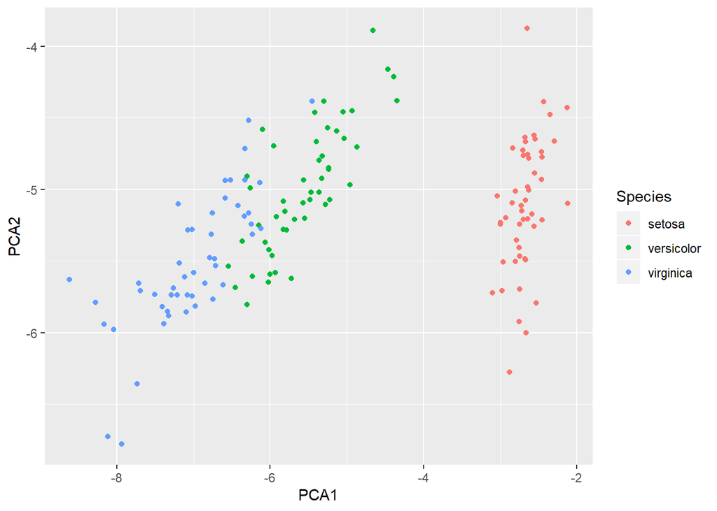

```r
data(iris)
iris <- data.table(iris)
scaled_iris <- scale(iris[, .SD, .SDcols = - "Species"])

# double checking that the results of eigen and svd are the same up to a sign change
expect_equivalent(abs(svd(cov(scaled_iris))$v), abs(eigen(cov(scaled_iris))$vectors))

iris_pca <- cbind((data.matrix(iris[, .SD, .SDcols = -"Species"]) %*% svd(cov(scaled_iris), nv = 2)$v), iris[, .SD, .SDcols ="Species"])
setnames(iris_pca, c("PCA1", "PCA2", "Species"))

ggplot(data = iris_pca)+
  geom_point(aes(x = PCA1, y = PCA2, color = Species))
```

PCA function:

```r
PCA = function(target, n_components = 2, standardize = T, return_eigenvectors = F){
  if(!is.matrix(target)){
    target <- as.matrix(target)
  }
  og_target <- target
  if(standardize){
    target = scale(target);
  }

  target_cov = cov(target);
  v_top <- svd(target_cov, nv = n_components)$v
  #reduced_target <- og_target %*% v_top
  reduced_target <- target %*% v_top
  if(return_eigenvectors){
    return(list("reduced_target"=reduced_target, "vectors"=v_top))
  }else{
    return(list("reduced_target"=reduced_target))
  }
}
```

#### cPCA: Contrastive PCA

Author’s written function in Python

- Description: Suppose you have two datasets, a `target` and a `background` where the `target` were a dataset containing information on cases and `background` contained information on controls, or uninteresting variation. cPCA works directly on the covariance matrices and seeks to find the directions/rotation (eigenvector) that maximizes the variance explained in the `target` and minimize the variance explained in the `background`. More specifically:

$$\begin{align*}
\textbf{v}^* &= \text{argmax}_{\textbf{v}\in \mathbb{R}^d_{unit}}{v^T\left(C_{target} - \alpha C_{bg}\right)v}
\end{align*}$$

Where $C_{target}$ and $C_{bg}$ are the sample covariance matrices.

- Function inputs:
  - `target`: Target dataset - dataset of interest
  - `bg`: Background dataset
  - `n_components`: number of Principal components to calculate
  - `alpha`: tuning parameter for how hard to weight minimizing the variance of the rotated background data
  - `return_all`: (logical) whether top eigenvectors should be returned
- Function outputs:
  - Data projected on the contrastive principal components

```r
cPCA = function(target, bg, n_components = 2, alpha = 1, standardize = T, return_all = F){

  if(!is.matrix(target) | !is.matrix(bg)){
    target <- as.matrix(target)
    bg <- as.matrix(bg)
  }
  og_target <- target

  if(standardize){
    target = scale(target);
    bg = scale(bg);
  }

  target_cov = cov(target);
  bg_cov = cov(bg);

  sigma = target_cov - alpha * bg_cov
  v_top <- svd(sigma, nv = n_components)$v
  #reduced_target <- og_target %*% v_top
  reduced_target <- target %*% v_top
  reduced_bg <- bg %*% v_top

  if(return_all){
    return(list("reduced_target" = reduced_target, "reduced_bg" = reduced_bg, "vectors" = v_top))
  }else{
    return(list("reduced_target" = reduced_target))
  }
}
```

#### occPCA: Orthogonal Complement cPCA

Description: Finding the principal components of the target data projected onto the space orthogonal to the vectors that explain the most variation in the background data

Advantages:

- You can repeat this procedure on more than 1 background dataset by repeatedly projecting onto the orthogonal complement of the background data.
- Since the objective function is not working on the covariance matrix, you can extend to other methods which have objective functions that work with the reconstruction error. NMF, penalized PCA, Factor Analysis, etc.
- Do not have to tune $\alpha$, the weight in cPCA, but still need to pick the number of dimensions that captures most of the variation in the background data. Arguably, there are already best practices (total variance explained/screeplot) for this and it’s less abstract/abitrary than tuning $\alpha$ in cPCA, and the results don’t differ much based on the tuning parameter

Procedure:

```r
occPCA = function(target, bg, n_components = 2, bg_components = 2, standardize = T, return_all = F){
  if(!is.matrix(target) | !is.matrix(bg)){
    target <- as.matrix(target)
    bg <- as.matrix(bg)
  }
  og_target <- target

  if(standardize){
    #target = scale(target,center = colMeans(bg),scale = apply(bg, 2, sd));
    target = scale(target)
    bg = scale(bg);
  }
  # Rotate the background
  bg_svd <-svd(bg, nv = bg_components)

  # Background Projection Matrix
  bg_projection <- tcrossprod(bg_svd$v)

  #projection onto the orthogonal complement
  oc_target <-  scale(target %*% (diag(nrow = nrow(bg_projection)) - bg_projection))

  reduced_target <- oc_target %*% svd(oc_target, nv = n_components)$v

  if(return_all){
    return(list("reduced_target" = reduced_target, "bg_svd" = bg_svd, "oc_target" = oc_target))
  }else{
    return(list("reduced_target" = reduced_target))
  }
}
```

Dave’s version of code OG:

1. did not project. $Xv$ was calculated, but not $X(I -P_{bg}) \Leftrightarrow Xv_{k+1:p}v_{k+1:p}^T$
2. Projecting using the last columns vs calculating the $I -P_{bg}$ yielded the same result

```r
X = targ[, .SD, .SDcols = -c("Genotype", "Treatment", "Behavior")]
B = background[, .SD, .SDcols = -c("Genotype", "Treatment", "Behavior")]

v = svd(scale(B, center = TRUE, scale = apply(B, 2, sd)), nv = ncol(B))$v
k = 2 ## first k PCs of B explain variation in background
newX = scale(X, center = colMeans(B), scale = apply(B, 2, sd)) %*% v[,-(1:k)] ## part of data not explained by v
newX = scale(newX, center = TRUE, scale = apply(newX, 2, sd))

reduced_target = data.table(scale(newX, center = TRUE, scale = apply(newX, 2, sd)) %*% svd(newX)$v[,1:2])
```

Stepping through the scale function, `scale(X)` is equivalent to `scale(X, center = T, scale = apply(X, 2, sd))`. For example:

```r
mouse <- fread('../contrastive/experiments/datasets/Data_Cortex_Nuclear.csv')
mouse <- NAtoZero(mouse)
background <- mouse[Behavior == "S/C" & Treatment == "Saline" & Genotype == "Ts65Dn", .SD, .SDcols = -c("MouseID","class")]

B = background[, .SD, .SDcols = -c("Genotype", "Treatment", "Behavior")]
expect_equivalent(scale(B), scale(B, center = T, scale = apply(B, 2, sd)))
```

Cleaned up for readability

```r
dave_occPCA = function(target,
                       bg,
                       n_components = 2,
                       bg_components = 2 ## first k PCs of B explain variation in background
                       ){
  X = data.matrix(target)
  B = data.matrix(bg)
  v = svd(scale(B))$v # SVD on scaled background data, no difference here

    newX = scale(X, center = colMeans(B), scale = apply(B, 2, sd)) %*% v[,-(1:bg_components)] ## part of data not explained by v
    newX = scale(newX, center = TRUE, scale = apply(newX, 2, sd))
    reduced_target = data.table(scale(newX, center = TRUE, scale = apply(newX, 2, sd)) %*% svd(newX)$v[,1:n_components])

  return(reduced_target)
}

mod_dave_occPCA = function(target,
                       bg,
                       n_components = 2,
                       bg_components = 2 ## first k PCs of B explain variation in background
                       ){
  X = data.matrix(target)
  B = data.matrix(bg)
  v = svd(scale(B))$v # SVD on scaled background data, no difference here
  selected_v <- v[,-(1:bg_components)]
  newX = scale(X, center = colMeans(B), scale = apply(B, 2, sd)) %*%  tcrossprod(selected_v) # why scale to the background??
  #newX = scale(newX)
  reduced_target = data.table(X %*% svd(scale(newX))$v[,1:n_components])
  return(reduced_target)
}
```

Questions to address: **Why scale the target data to the background** **You’re visualizing the data via principal components. Should visualized data be scaled**

### Replicating Figure 3a. in the paper

Authors Data Analysis

The original data had some missing data in it. From the Author’s anaylsis, missing values were turned to zero.

```r
mouse <- fread('../contrastive/experiments/datasets/Data_Cortex_Nuclear.csv')
mouse <- NAtoZero(mouse)

targ <- mouse[Behavior == "S/C" & Treatment == "Saline" & Genotype %in% c("Control", "Ts65Dn"), .SD, .SDcols = -c("MouseID","class")]
background <- mouse[Behavior == "S/C" & Treatment == "Saline" & Genotype == "Ts65Dn", .SD, .SDcols = -c("MouseID","class")]
```

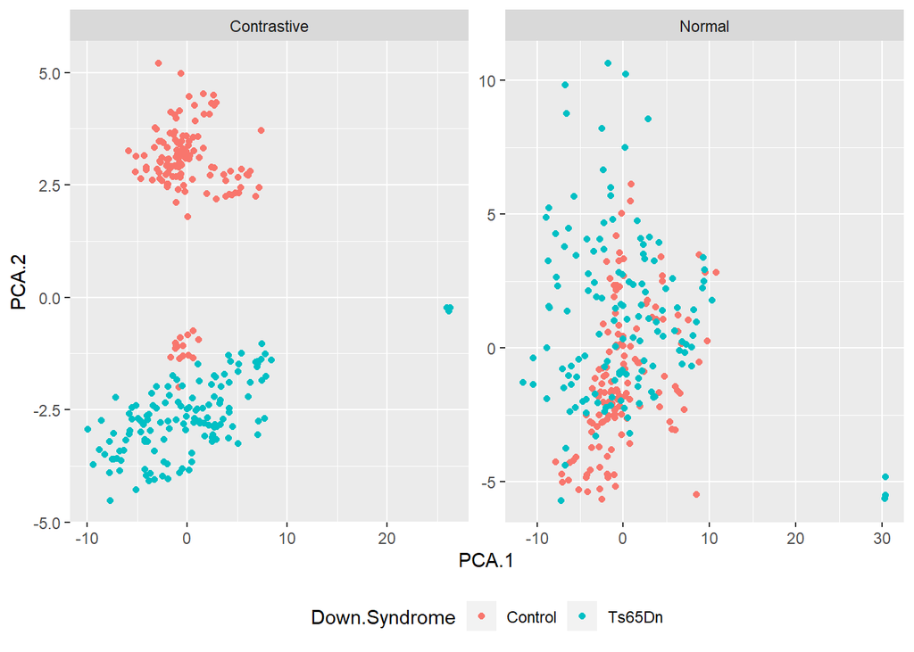

```r
results_cPCA <- cPCA(target = targ[, .SD, .SDcols = -c("Genotype", "Treatment", "Behavior")],
     bg = background[, .SD, .SDcols = -c("Genotype", "Treatment", "Behavior")],
     alpha = 1)

reduced_target <- data.table(results_cPCA[[1]])
reduced_target <- cbind(reduced_target,  targ[, .SD, .SDcols = c("Genotype")], "Contrastive")

normal_pca <- data.table(PCA(target = targ[, .SD, .SDcols = -c("Genotype", "Treatment", "Behavior")])[[1]])
normal_pca <- cbind(normal_pca, targ[, .SD, .SDcols = c("Genotype")], "Normal")

first_pass_plot <- rbind(reduced_target, normal_pca)
setnames(first_pass_plot, c("PCA.1", "PCA.2", "Down.Syndrome", "Method"))

ggplot(data = first_pass_plot)+
  geom_point(aes(x = PCA.1, y=PCA.2, color = Down.Syndrome))+
  facet_wrap(~Method, scale = "free")+
  theme(legend.position = "bottom")
```

#### Playing with the tuning parameter alpha

Contrastive PCA seems very sensitive to the tuning parameter $\alpha$

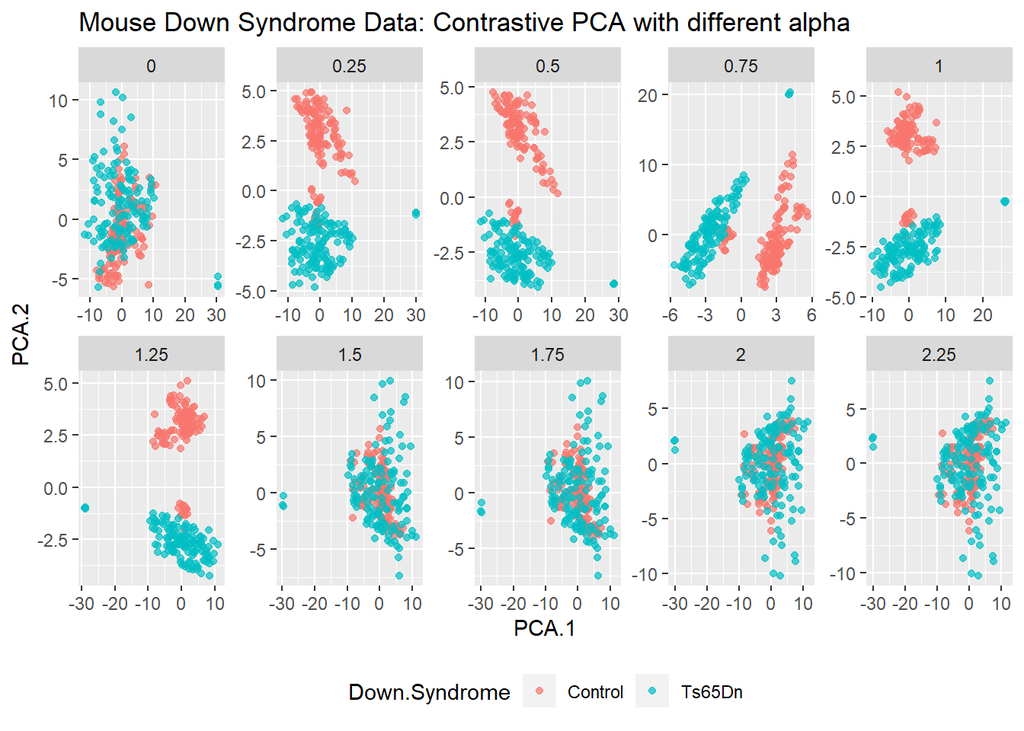

```r
search_grid <- seq(0, 2.25, by = 0.25)

tuning_alpha <- lapply(search_grid, function(xx) cPCA(target = targ[, .SD, .SDcols = -c("Genotype", "Treatment", "Behavior")],
     bg = background[, .SD, .SDcols = -c("Genotype", "Treatment", "Behavior")],
     alpha = xx))

tuning_alpha_plot <- data.table(do.call(rbind, lapply(tuning_alpha, "[[", 1)),
                                sort(rep(search_grid, nrow(targ))),
                                unlist(rep(targ[, "Genotype"],length(search_grid))))
setnames(tuning_alpha_plot, c("PCA.1", "PCA.2", "alpha", "Down.Syndrome"))

ggplot(data = tuning_alpha_plot)+
  geom_point(aes(x = PCA.1, y = PCA.2, color = Down.Syndrome), alpha = 0.7)+
  facet_wrap(~alpha, scales = "free", nrow = 2)+
  theme(legend.position = "bottom")+
  labs(title = "Mouse Down Syndrome Data: Contrastive PCA with different alpha")
```

Using the log spaced values for the tuning parameter $\alpha$… They chose the best $\alpha$ based on Spectral Clustering

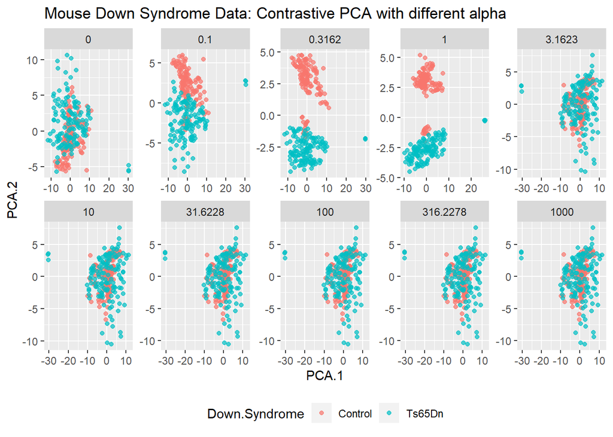

```r
search_grid2 <- c(0, 10^(seq(-1, log10(1000), length.out = 9)))

tuning_alpha <- lapply(search_grid2, function(xx) cPCA(target = targ[, .SD, .SDcols = -c("Genotype", "Treatment", "Behavior")],
     bg = background[, .SD, .SDcols = -c("Genotype", "Treatment", "Behavior")],
     alpha = xx))

tuning_alpha_plot <- data.table(do.call(rbind, lapply(tuning_alpha, "[[", 1)),
                                sort(rep(round(search_grid2, 4), nrow(targ))),
                                unlist(rep(targ[, "Genotype"],length(search_grid2))))
setnames(tuning_alpha_plot, c("PCA.1", "PCA.2", "alpha", "Down.Syndrome"))

ggplot(data = tuning_alpha_plot)+
  geom_point(aes(x = PCA.1, y = PCA.2, color = Down.Syndrome), alpha = 0.7)+
  facet_wrap(~alpha, scales = "free", nrow = 2)+
  theme(legend.position = "bottom")+
  labs(title = "Mouse Down Syndrome Data: Contrastive PCA with different alpha")
```

#### occPCA

```r
results_occPCA <- occPCA(target = targ[, .SD, .SDcols = -c("Genotype", "Treatment", "Behavior")],
     bg = background[, .SD, .SDcols = -c("Genotype", "Treatment", "Behavior")],
     bg_components = 3,
     return_all = T)

occ_reduced_target <- data.table(results_occPCA[[1]])
occ_reduced_target <- cbind(occ_reduced_target,  targ[, .SD, .SDcols = c("Genotype")], "OCC")

setnames(occ_reduced_target, c("PCA.1", "PCA.2", "Down.Syndrome", "Method"))

second_pass_plot <- rbind(first_pass_plot[Method == "Contrastive"], occ_reduced_target)
```

#### diagnostic plots for the background data

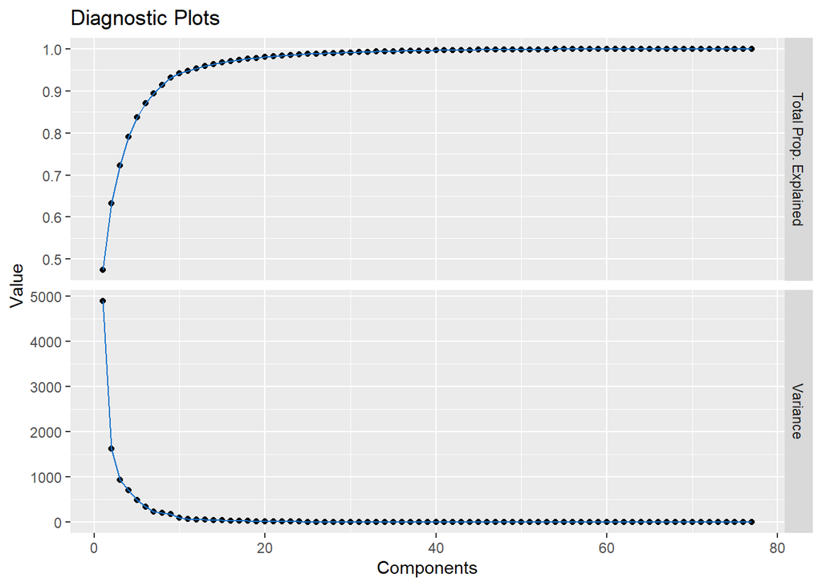

```r
#screeplot
scree(results_occPCA$bg_svd)
```

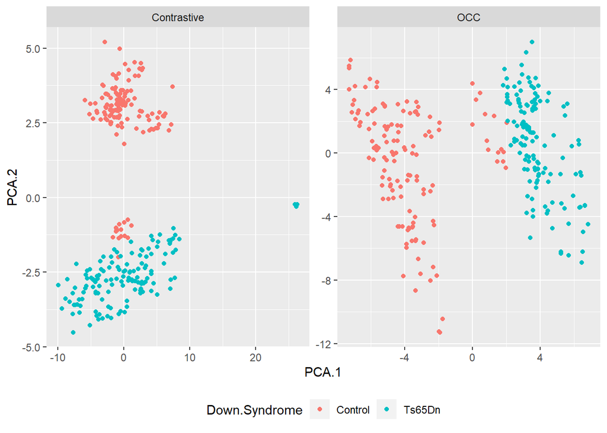

```r
ggplot(data = second_pass_plot)+
  geom_point(aes(x = PCA.1, y=PCA.2, color = Down.Syndrome))+
  facet_wrap(~Method, scale = "free")+
  theme(legend.position = "bottom")
```

### Playing with the tuning bg_components

The results are robust to first $k$ number of background principal components, unlike choosing the $\alpha$ parameter in cPCA. Clean seperation occurs at every $k$ background principal components.

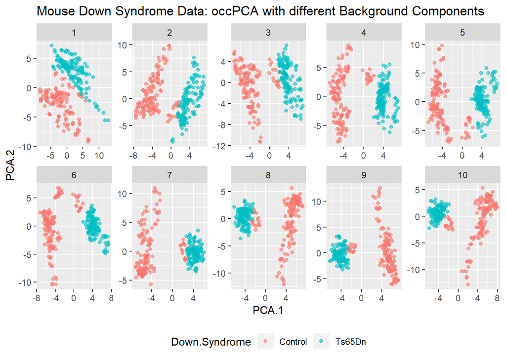

```r
search_grid <- 1:10

tuning_bg <- lapply(search_grid, function(xx) occPCA(target = targ[, .SD, .SDcols = -c("Genotype", "Treatment", "Behavior")],
     bg = background[, .SD, .SDcols = -c("Genotype", "Treatment", "Behavior")],
     bg_components = xx))

tuning_bg_plot <- data.table(do.call(rbind, lapply(tuning_bg, "[[", 1)),
                                sort(rep(search_grid, nrow(targ))),
                                unlist(rep(targ[, "Genotype"],length(search_grid))))
setnames(tuning_bg_plot, c("PCA.1", "PCA.2", "alpha", "Down.Syndrome"))

ggplot(data = tuning_bg_plot)+
  geom_point(aes(x = PCA.1, y = PCA.2, color = Down.Syndrome), alpha = 0.6)+
  facet_wrap(~alpha, scales = "free", nrow = 2)+
  theme(legend.position = "bottom")+
  labs(title = "Mouse Down Syndrome Data: occPCA with different Background Components")
```

## Checking Dave’s Code

tuning_g for dave’s code

### Using Dave’s pretty much OG code

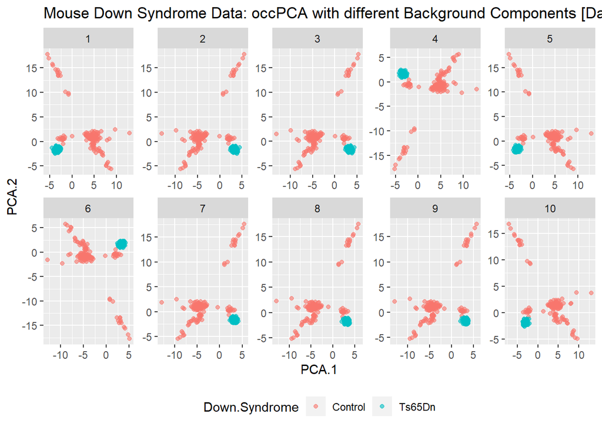

```r
search_grid <- 1:10

#Dave's code in function form
tuning_bg_dave1 <- lapply(search_grid, function(xx) dave_occPCA(target = targ[, .SD, .SDcols = -c("Genotype", "Treatment", "Behavior")],
     bg = background[, .SD, .SDcols = -c("Genotype", "Treatment", "Behavior")],
     bg_components = xx))

tuning_bg_dave_plot1 <- data.table(do.call(rbind, tuning_bg_dave1),
                                sort(rep(search_grid, nrow(targ))),
                                unlist(rep(targ[, "Genotype"],length(search_grid))))

setnames(tuning_bg_dave_plot1, c("PCA.1", "PCA.2", "alpha", "Down.Syndrome"))

ggplot(data = tuning_bg_dave_plot1)+
  geom_point(aes(x = PCA.1, y = PCA.2, color = Down.Syndrome), alpha = 0.6)+
  facet_wrap(~alpha, scales = "free", nrow = 2)+
  theme(legend.position = "bottom")+
  labs(title = "Mouse Down Syndrome Data: occPCA with different Background Components [Daves Code]")
```

### Modified to remove a bunch of scaling to verify same results

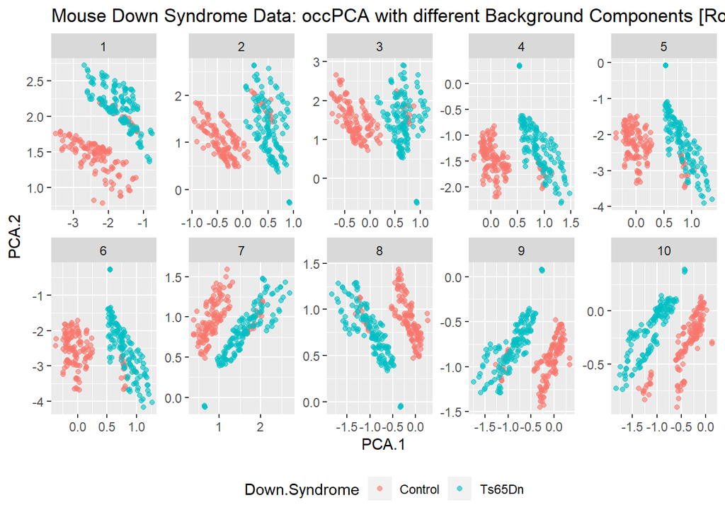

```r
#Robin modifies Dave's code in function form
tuning_bg_dave2 <- lapply(search_grid, function(xx) mod_dave_occPCA(target = targ[, .SD, .SDcols = -c("Genotype", "Treatment", "Behavior")],
     bg = background[, .SD, .SDcols = -c("Genotype", "Treatment", "Behavior")],
     bg_components = xx))

tuning_bg_dave_plot2 <- data.table(do.call(rbind, tuning_bg_dave2),
                                sort(rep(search_grid, nrow(targ))),
                                unlist(rep(targ[, "Genotype"],length(search_grid))))

setnames(tuning_bg_dave_plot2, c("PCA.1", "PCA.2", "alpha", "Down.Syndrome"))

ggplot(data = tuning_bg_dave_plot2)+
  geom_point(aes(x = PCA.1, y = PCA.2, color = Down.Syndrome), alpha = 0.6)+
  facet_wrap(~alpha, scales = "free", nrow = 2)+
  theme(legend.position = "bottom")+
  labs(title = "Mouse Down Syndrome Data: occPCA with different Background Components [Robin mod Daves Code]")
```